# Superbowl_Part2_Rscript

Venkata Surendra Reddy Gujjula

05-Feb-2024

Use control+Enter to run the code chunks on PC. Use command+Enter to run the code chunks on MAC.

## Load Packages

In this section, we install and load the necessary packages.

## Import Data

In this section, we import the necessary data for this lab.

# Homework Assignment 2: Super Bowl Caselet (Part 2)

You are hired as a Business Analyst to help the manager to find out if spending millions of dollars on Super Bowl ads creates social media buzz.

As a second step, carry out descriptive analysis on superbowl.csv data. There are some questions for each sections that you need to answer.

## Section 1: Univariate Statistics

Task 1, compute the *mean*, *variance*, and *standard deviation* of **adspend** for each **new_brand** before the Super Bowl and after the Super Bowl. Hint: you may use dplyr functions group_by() and summarise().

Note that the superbowl column is 0 for the weeks before super bowl and 1 for the weeks of or after super bowl.

```r
superbowl %>%
  group_by(new_brand, superbowl) %>%
  summarise(
    mean_adspend = mean(adspend),
    variance_adspend = var(adspend),
    sd_adspend = sd(adspend)
  )
```

```
## # A tibble: 6 × 5
## # Groups:   new_brand [3]
##   new_brand superbowl mean_adspend variance_adspend sd_adspend
##   <chr>         <int>        <dbl>            <dbl>      <dbl>
## 1 Beetle            0        2.17            2.18        1.48
## 2 Beetle            1      891.        4839676.       2200.
## 3 CR-Z              0        1.25            0.703       0.839
## 4 CR-Z              1        0.709           0.0529      0.230
## 5 Camaro            0       71.1           156.         12.5
## 6 Camaro            1      518.        1335443.       1156.
```

Task 2, compute the *mean* and *standard deviation* of **volume** (the number of total mentions form social media), **pos** (the number of positive mentions) and **neg** (the number of negative mentions) for each **new_brand** before the Super Bowl and after the Super Bowl.

```r
superbowl %>%
  group_by(new_brand, superbowl) %>%
  summarise(
    mean_volume = mean(volume),
    sd_volume = sd(volume),
    mean_pos = mean(pos),
    sd_pos = sd(pos),
    mean_neg = mean(neg),
    sd_neg = sd(neg)
  )
```

```
## # A tibble: 6 × 8
## # Groups:   new_brand [3]
##   new_brand superbowl mean_volume sd_volume mean_pos sd_pos mean_neg sd_neg
##   <chr>         <int>       <dbl>     <dbl>    <dbl>  <dbl>    <dbl>  <dbl>
## 1 Beetle            0       3418.      622.     659.   91.8     86.5   17.2
## 2 Beetle            1       4319.     1463.     965.  455.     156.   100.
## 3 CR-Z              0       1172.      266.     268    53.7     60.5   33.8
## 4 CR-Z              1       1486.      712.     339.  136.      49.8   21.6
## 5 Camaro            0      87596.     7817.   21432  2610.    4458.   334.
## 6 Camaro            1      93613.    22222.   23509. 6351.    4679.  1333.
```

Then, answer the following questions. Please write your answers after **Response**:

**Questions**:

1. What brand has the **highest mean ad spend** after the Super Bowl? Has the mean ad spending increased after the Super Bowl for that brand? By how much?
2. What brand has the **highest mean** volume of mentions after the Super Bowl? What brand has the **lowest mean** volume of **positive** mentions after the Super Bowl?

**Responses**: **PLEASE ADD YOUR RESPONSES HERE**

1.’Beetle’ has the highest mean as spend after the Super Bowl. Yes the mean ad spend is increased after the Super Bowl which is 891-2.17=888.83.

2. ‘Camaro’ has the highest mean volume of mentions after the Super Bowl which is 93613.’CR-Z’ has the lowest mean volume of positive mentions after the Super Bowl.

### Section 2: Bivariate Statistics

Task 1, compute the *correlation* between **adspend** and **volume** in superbowl dataset, before the Super Bowl and after the Super Bowl. Similarly, compute the *correlation* between **adspend** and **pos**, and between **adspend** and **neg** in superbowl dataset, before the Super Bowl and after the Super Bowl. Hint: you may use dplyr functions group_by() and summarise().

```r
superbowl %>%
  group_by(superbowl) %>%
  summarise(
    cor_adspend_volume = cor(adspend, volume),
    cor_adspend_pos = cor(adspend, pos),
    cor_adspend_neg = cor(adspend, neg)
  )
```

```
## # A tibble: 2 × 4
##   superbowl cor_adspend_volume cor_adspend_pos cor_adspend_neg
##       <int>              <dbl>           <dbl>           <dbl>
## 1         0             0.975           0.975           0.979
## 2         1             0.0513          0.0536          0.0495
```

Task 2, for each **new_brand**, compute the *correlation* between **adspend** and **volume**, between **adspend** and **pos**, and between **adspend** and **neg**, before the Super Bowl and after the Super Bowl.

```r
superbowl %>%
  group_by(new_brand, superbowl) %>%
  summarise(
    cor_adspend_volume = cor(adspend, volume),
    cor_adspend_pos = cor(adspend, pos),
    cor_adspend_neg = cor(adspend, neg)
  )
```

```
## # A tibble: 6 × 5
## # Groups:   new_brand [3]
##   new_brand superbowl cor_adspend_volume cor_adspend_pos cor_adspend_neg
##   <chr>         <int>              <dbl>           <dbl>           <dbl>
## 1 Beetle            0             -0.152         -0.339          -0.530
## 2 Beetle            1              0.478          0.470           0.377
## 3 CR-Z              0              0.246          0.0503         -0.156
## 4 CR-Z              1              0.396          0.264           0.302
## 5 Camaro            0             -0.104          0.0569          0.0176
## 6 Camaro            1              0.115          0.116           0.0980
```

Then, answer the following questions. Please write your answers after **Response**:

**Questions**:

1. What is the *correlation* between **adspend** and **pos** before AND after the Super Bowl? Does that imply a positive, negative or no relationship? Is the relationship strong? What about the relationship between **adspend** and **neg** before AND after the Super Bowl?
2. Which brand’s ad spending did actually create a social media buzz (either positive or negative mentions)? Use both univariate and bivariate statistics for each brand to support your answer.

**Responses**: **PLEASE ADD YOUR RESPONSES HERE**

1.The correlation between ‘adspend’ and ‘pos’ is strong and positive correlation of 0.975 which is a very strong positive linear relationship between ad spending and the number of positive mentions before the Super Bowl.After the Super Bowl the correlation is positive but weak which is 0.0536 indicates a weak positive linear relationship. The strength of the relationship has substantially decreased.

The correlation between ‘adspend’ and ‘neg’ is strong and positive correlation of 0.979 which is a very strong positive linear relationship between ad spending and the number of positive mentions before the Super Bowl.After the Super Bowl the correlation is positive but weak which is 0.0495 indicates a weak positive linear relationship. The strength of the relationship has substantially decreased.

2.’Beetle’ adspend has created a social media buzz when compare to the other two brands.We can observe this in the both positive and negative emotions there is significant change in correlation. For positive emotions before Super Bowl it is weak negative correlation(-0.339) and after the Super Bowl it is moderate positive correlation(0.470) and if we consider the numbers in univariate the positive emotions are increased from 659 to 965 which is 46.52% increase in the emotions which means it created a much good impact on social media.

Even though the numbers are high for the ‘Camaro’ but the change is very minimal the adspend has no much impact on the values as the correlation of positive emotions before the Super Bowl is very weak positive(0.0569) and after the Super Bowl the just positive(0.116) there is no much significant change and also if we consider the univariate positive emotions numbers which is increased from 21432 to 23509 which is 9.68% increase which is not much for the adspend.

In conclusion ‘Beetle’ adspend has created more social media buzz in volume,positive and negative emotions.

```r
 superbowl %>%
       filter(new_brand == "Beetle") %>%
       select(time, volume, new_brand,adspend)
```

```
##    time volume new_brand adspend
## 1     1   2661    Beetle     2.7
## 2     2   3620    Beetle     4.0
## 3     3   4138    Beetle     1.3
## 4     4   3255    Beetle     0.7
## 5     5   5144    Beetle  7105.0
## 6     6   8021    Beetle  2576.2
## 7     7   3728    Beetle    41.2
## 8     8   4396    Beetle    42.8
## 9     9   4297    Beetle    19.8
## 10   10   4326    Beetle     0.3
## 11   11   3870    Beetle     1.4
## 12   12   3840    Beetle     2.5
## 13   13   4240    Beetle     4.3
## 14   14   3760    Beetle     2.3
## 15   15   1885    Beetle     0.9
```

```r
 superbowl %>%
       filter(new_brand == "Camaro") %>%
       select(time, volume, new_brand,adspend)
```

```
##    time volume new_brand adspend
## 1     1  78030    Camaro    75.3
## 2     2  84868    Camaro    61.0
## 3     3  91640    Camaro    86.9
## 4     4  95844    Camaro    61.2
## 5     5  98910    Camaro  3977.6
## 6     6 100034    Camaro   272.1
## 7     7  94030    Camaro    59.9
## 8     8 101664    Camaro    72.7
## 9     9 107356    Camaro    88.9
## 10   10 108438    Camaro   202.5
## 11   11 104014    Camaro   132.3
## 12   12  92904    Camaro   105.5
## 13   13 107044    Camaro   534.0
## 14   14  85274    Camaro   165.3
## 15   15  30078    Camaro    82.4
```

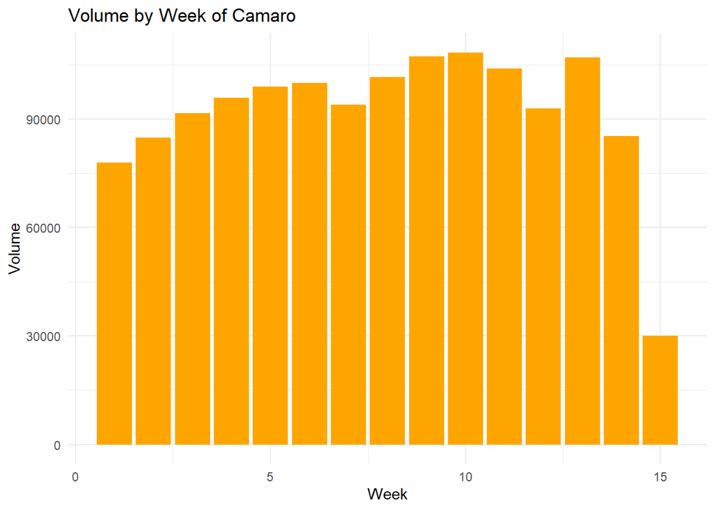

```r
ggplot(superbowl %>% filter(new_brand=="Camaro"), aes(x = time, y = volume)) +
  geom_bar(position = "dodge", stat = "identity",fill="Orange"  ) +
  labs(title = "Volume by Week of Camaro",
       x = "Week",
       y = "Volume") +
  theme_minimal()
```

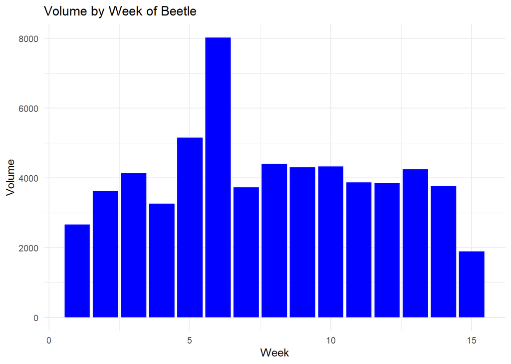

```r
ggplot(superbowl %>% filter(new_brand=="Beetle"), aes(x = time, y = volume)) +
  geom_bar(position = "dodge", stat = "identity",  fill = "Blue") +
  labs(title = "Volume by Week of Beetle",
       x = "Week",
       y = "Volume") +
  theme_minimal()
```

[figure not shown]

```r
ggplot(superbowl %>% filter(new_brand=="Camaro"), aes(x = adspend, y = volume)) +
  geom_point() +
  scale_x_log10() +
  geom_smooth(method = "lm", se = FALSE, colour = "Orange") +
  labs(title = "AdSpend Vs Volume of Camaro") +
  ylab("Adspend") +
  xlab("Volume")
```

[figure not shown]

```r
ggplot(superbowl %>% filter(new_brand=="Beetle"), aes(x = adspend, y = volume)) +
  geom_point() +
  scale_x_log10() +
  geom_smooth(method = "lm", se = FALSE, colour = "Blue") +
  labs(title = "AdSpend Vs Volume of Beetle") +
  ylab("Adspend") +
  xlab("Volume")
```